# Spatiotemporal analyses with epiCo

**epiCo**’s *spatiotemporal* module is a tool to analyze the spatial correlation of cases based on their coordinates of notification and the real travel times within Colombian territory.

The *spatiotemporal* module allows users to:

- Define the neighbors of a municipality based on a travel time threshold that accounts for real connectivity and infrastructure in Colombia.
- Perform a Moran’s Index autocorrelation analysis on the defined neighborhood and the provided incidence data (internally converted to incidence rate).
- Plot a map with the High (spatial correlation) - High (incidence rate) clusters, as well as Low (spatial correlation) - Low (incidence rate) clusters.

In the following vignette, you will learn:

1. How real travel times were estimated from Colombian connectivity and infrastructure.
2. To obtain the neighbors of a municipality from real travel times using the `neighborhoods` function.
3. To use **epiCo**’s `morans_index` function.
4. How to interpret and communicate the results.

## 1. Real travel times among Colombian municipalities

Several approaches to estimating the proximity and neighborhood of a point (or region) are developed in the literature. Some rely on euclidean distances among the centroids of the areas, whereas others rely on contiguity approaches between their boundaries.

**epiCo** aims to propose a new approach to neighborhood estimation by defining the proximity among municipalities based on the real available infrastructure in the territory. This is important in countries like Colombia, where topology shapes the connectivity and interaction between municipalities and where Euclidean distances and boundaries may lead to an overestimation of nearness when in reality one of the three mountain ranges or one of the several rivers in the country may lead to large travel distances and times.

To estimate real travel times among Colombian municipalities, a travel times matrix was calculated based on the [Bravo-Vega C., Santos-Vega M., & Cordovez J.M. (2022)](https://doi.org/10.1371/journal.pntd.0011117) study. The travel times account for the fastest path to connect one municipality to all municipalities in a friction map that provides different speeds according to the presence and quality of the roads, fluvial transport, or walking possibilities.

## 2. Defining a neighborhood with **epiCo**

Since **epiCo** stores all travel times among municipalities in Colombia, the definition of a neighborhood has to be based on the expertise and knowledge of the user regarding the maximum travel time for which a municipality is considered a neighbor.

The `neighborhoods` function receives as parameters a vector of DIVIPOLA codes accounting for the municipalities to consider as potential neighbors and a threshold that accounts for the maximum travel time (in hours) that a municipality can be from another.

```r
library(epiCo)
library(dplyr)
library(incidence)
data(divipola_table)
cundinamarca_data <- dplyr::filter(
  divipola_table,
  NOM_DPTO == "CUNDINAMARCA"
) %>%
  select(COD_MPIO, LATITUD, LONGITUD)

cundinamarca_neighborhood <- neighborhoods(
  query_vector = cundinamarca_data$COD_MPIO,
  threshold = 0.5
)$neighbours
```

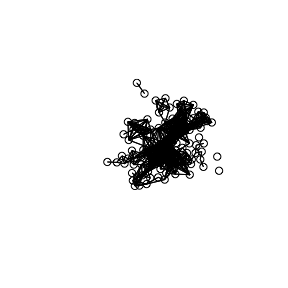

Neighbor municipalities of Cundinamarca with a 0.5-hour threshold.

```r
plot(cundinamarca_neighborhood, cbind(
  cundinamarca_data$LATITUD,
  cundinamarca_data$LONGITUD
))
```

## 3. *epiCo*’s `morans_index` function

*epiCo* provides a function to perform a [Local Moran’s index analysis](https://r-spatial.github.io/spdep/reference/moran.plot.html) from an [`incidence`](https://www.repidemicsconsortium.org/incidence/) object with unique observations for a set of Colombian municipalities.

Internally, the function reads the `incidence` object’s groups as the DIVIPOLA codes to:

1. Estimate incidence rates using **epiCo**’s `incidence_rate` function.
2. Evaluate them on the **epiCo**’s `neighborhoods` function.

The following example uses the cases of the municipalities of Tolima for the year 2019.

```r
data("epi_data")

data_tolima <- epi_data[lubridate::year(epi_data$fec_not) == 2019, ]
incidence_object <- incidence(
  dates = data_tolima$fec_not,
  groups = data_tolima$cod_mun_o,
  interval = "12 months"
)

morans_tolima <- morans_index(
  incidence_object = incidence_object
)
```

```
#> Significant municipalities are:
#> 73024 with Low-High (incidence - spatial correlation)
#> 73226 with High-High (incidence - spatial correlation)
#> 73555 with High-High (incidence - spatial correlation)
#> 73675 with High-High (incidence - spatial correlation)
```

```r
morans_tolima$plot
```

[interactive chart not shown]

Local Moran’s index clusters for the incidence of Tolima municipalities in 2019.

## 4. Interpretation and communication of *epiCo*’s `morans_index` results

High-high clusters represent areas with high incidence rate surrounded by other areas with high incidence rates, suggesting a spatial cluster of elevated risk (e.g., a disease hotspot).

Similarly, low-low clusters indicate areas with low incidence rates surrounded by other low incidence rates areas.

High-low or low-high clusters represent areas with dissimilar values neighboring each other and may not lead to significant conclusions regarding spatial behavior of the disease.

Nevertheless, is important to recall that a cluster map (as the one created by the *epiCo*’s `morans_index` function) is a complementary tool to understand the spatiotemporal behavior of a disease, but is limited to provide explicit information regarding (for example) allocation of resources. Comparisons with other methodologies and with epidemiology experience should be done to address epidemic responses.

In addition, risk communication should share simple and interpretable results. If public opinion may be misleaded or confused by the clusters analysis, simpler visualization of disease behavior as heatmaps should be used.